# Causal inference approach aimed to hybrid control arm design

# 6 Outcome OLS - Multi-covariate adjustment

If Z blocks backdoors and model is correct, the βA targets ATT.

These models are sensitive to misspecification, omitted interactions or nonlinearity.

```r
# g-formula via regression
outcome_ml <- lm(
  cr_pr_4m ~ treat_drug + sex + age + race + bmi + ECOG,
  data = df_all
)

outcome_ml
```

```
Call:
lm(formula = cr_pr_4m ~ treat_drug + sex + age + race + bmi +
    ECOG, data = df_all)

Coefficients:
  (Intercept)  treat_drugYES        sexMale            age      raceWhite
     0.547761       0.510072      -0.214490      -0.006577       0.115838
     bmi25-30        bmi>=30         ECOG>1
     0.106406      -0.163012       0.108884
```

# 7 Propensity Score Methods (PSM)

We estimate the propensity score (PS):

```r
# Dataset for external-control alignment:
# treated = trial YES
# control = external RWD NO

df_ps <- df_all %>%
  filter(
    (source == "trial" & treat_drug == "YES") |
      (source == "rwd" & treat_drug == "NO")
  )
```

```r
ps_model <- glm(
  treat_drug ~ age + sex + race + bmi + ECOG,
  data = df_ps,
  family = binomial()
)

df_ps$ps <- predict(ps_model, type = "response")
```

```r
# Aim for |SMD| < 0.1 after adjustment
bal <- bal.tab(
  treat_drug ~ age + sex + race + bmi + ECOG,
  data = df_ps,
  estimand = "ATT",
  un = TRUE # show unadjusted differences
)

bal
```

```
Balance Measures
              Type Diff.Un
age        Contin.  0.1881
sex_Male    Binary  0.1632
race_White  Binary -0.2708
bmi_<25     Binary  0.0729
bmi_25-30   Binary -0.0938
bmi_>=30    Binary  0.0208
ECOG_>1     Binary -0.2465

Sample sizes
    NO YES
All 18  32
```

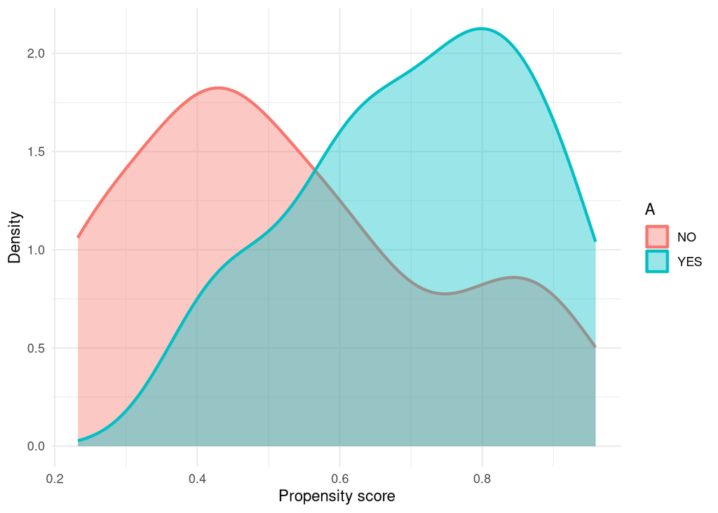

Figure 3: PS baseline imbalance - Raw PS overlap (before any method)

```r
# Raw PS overlap (before any method)
ggplot(
  df_ps,
  aes(x = ps, fill = factor(treat_drug), color = factor(treat_drug))
) +
  geom_density(alpha = .4, linewidth = 1) +
  labs(
    x = "Propensity score",
    y = "Density",
    fill = "A",
    color = "A"
  ) +
  theme_minimal()
```

## 7.1 Inverse Probability Weighting and Balancing

Create a “pseudo-population” where the distribution of measured baseline covariates is almost perfectly balanced. Every patient is assigned with a weight equal to the inverse of the probability of receiving the treatment that actually received.

### 7.1.1 IPTW-ATT Stabilized weights

Stabilized weights are often preferred because of its variance control, not bias correction.

*Note: same final results can be obtained using WeightIt package.*

```r
df_att <- df_ps %>%
  mutate(
    w_att = ifelse(
      treat_drug == "YES",
      1,
      ps / (1 - ps)
    )
  )
```

```r
#' The IPTW-ATT weights received by the external control arm subjects will
#' be multiplied by (1−1/r) to accurately refect the contribution of the ECA in the HCA.
#' Majumdar et al 2022. Their goal is to have a 1:1 ratio between Tx and Pbo.
r <- 32 / 16 # or more generally n_treated (32) / n_internal_control (16) = 2

# Extract external NO weights from the external-control alignment step
ext_aza_att <- df_att %>%
  filter(source == "rwd") %>%
  dplyr::select(patient_id, w_att)

# Re-join weighted external NO with internal trial controls
df_hybrid_att <- df_all %>%
  left_join(ext_aza_att, by = "patient_id") %>%
  mutate(
    hybrid_w = case_when(
      source == "trial" & treat_drug == "YES" ~ 1,
      source == "trial" & treat_drug == "NO" ~ 1,
      source == "rwd" & treat_drug == "NO" ~ (1 - 1 / r) * w_att
    )
  )
```

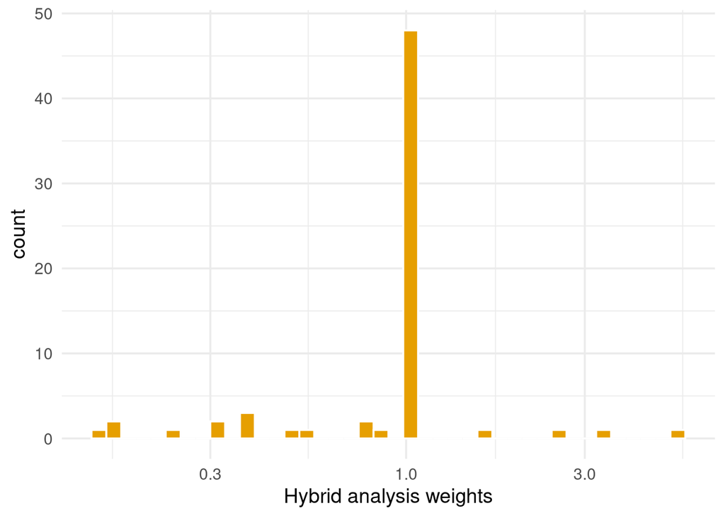

Figure 4: Distribution of weights in the stabilized hybrid control analysis

```r
ggplot(df_hybrid_att, aes(hybrid_w)) +
  geom_histogram(color = "white", fill = "#E69F00", bins = 40) +
  scale_x_log10() +
  theme_minimal(base_size = 14) +
  xlab("Hybrid analysis weights")
```

```r
bal_att <- bal.tab(
  treat_drug ~ age + sex + race + bmi + ECOG,
  data = df_att,
  weights = df_att$w_att,
  estimand = "ATT",
  un = TRUE
)

bal_att
```

```
Balance Measures
              Type Diff.Un Diff.Adj
age        Contin.  0.1881   0.0081
sex_Male    Binary  0.1632  -0.1406
race_White  Binary -0.2708   0.1107
bmi_<25     Binary  0.0729  -0.0315
bmi_25-30   Binary -0.0938  -0.0695
bmi_>=30    Binary  0.0208   0.1010
ECOG_>1     Binary -0.2465   0.0210

Effective sample sizes
              NO YES
Unadjusted 18.    32
Adjusted    6.76  32
```

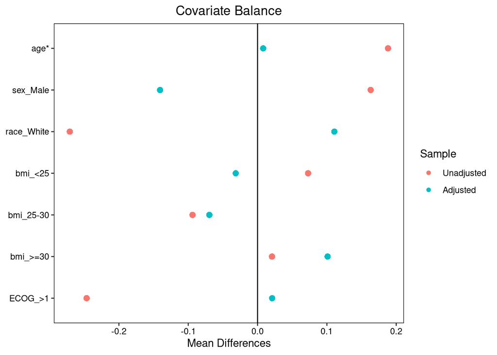

Figure 5: Covariate balance after stabilized ATT weighting

```r
love.plot(
  bal_att,
  binary = "std",
  stats = "mean.diffs",
  stars = "std"
)
```

#### 7.1.1.1 Causal effect estimation with IPTW

In lm weighted regression the point estimate is correct, but the variance may be underestimated when weights represent sampling or IPW weights.

Thus after this the variance should be corrected, for example with robust SE approach or bootstrap.

##### 7.1.1.1.1 Weigthed regression without correction

```r
# outcome analysis
hybrid_fit_att <- lm(
  cr_pr_4m ~ treat_drug,
  data = df_hybrid_att,
  weights = hybrid_w
)

summary(hybrid_fit_att)
```

```
Call:
lm(formula = cr_pr_4m ~ treat_drug, data = df_hybrid_att, weights = hybrid_w)

Weighted Residuals:
     Min       1Q   Median       3Q      Max
-0.56250 -0.12310 -0.07205  0.43750  0.91995

Coefficients:
              Estimate Std. Error t value Pr(>|t|)
(Intercept)    0.08005    0.06834   1.171    0.246
treat_drugYES  0.48245    0.09886   4.880 7.37e-06 ***
---
Signif. codes:  0 '***' 0.001 '**' 0.01 '*' 0.05 '.' 0.1 ' ' 1

Residual standard error: 0.4041 on 64 degrees of freedom
Multiple R-squared:  0.2712,    Adjusted R-squared:  0.2598
F-statistic: 23.82 on 1 and 64 DF,  p-value: 7.369e-06
```

##### 7.1.1.1.2 Weigthed regression with robust SEs

```r
hybrid_fit_att_robust <- coeftest(
  hybrid_fit_att,
  vcov = vcovHC(hybrid_fit_att, type = "HC0")
)

hybrid_att_results <- hybrid_fit_att_robust %>%
  tidy(conf.int = TRUE) %>%
  filter(term == "treat_drugYES")

hybrid_att_results
```

```
# A tibble: 1 × 7
  term          estimate std.error statistic    p.value conf.low conf.high
  <chr>            <dbl>     <dbl>     <dbl>      <dbl>    <dbl>     <dbl>
1 treat_drugYES    0.482    0.0979      4.93 0.00000618    0.287     0.678
```

#### 7.1.1.2 Weigthed regression with bootstrap confidence intervals

```r
fit_hybrid_ipw <- function(.split, ...) {
  # bootstrap sample from the full dataset
  .df <- as.data.frame(.split) %>%
    mutate(row_id_boot = row_number())

  # -----------------------------
  # Stage 1: external-control alignment
  # treated = trial YES
  # control = external RWD NO
  # -----------------------------
  .df_ps <- .df %>%
    filter(
      (source == "trial" & treat_drug == "YES") |
        (source == "rwd" & treat_drug == "NO")
    )

  # fit PS model in bootstrap sample
  propensity_model <- glm(
    treat_drug ~ sex + age + race + bmi + ECOG,
    family = binomial(),
    data = .df_ps
  )

  # predicted PS for P(YES | Z)
  .df_ps <- propensity_model %>%
    augment(type.predict = "response", data = .df_ps) %>%
    mutate(
      w_att = ifelse(
        treat_drug == "YES",
        1,
        .fitted / (1 - .fitted)
      )
    )

  # keep only external NO weights to re-join later
  ext_weights <- .df_ps %>%
    filter(source == "rwd", treat_drug == "NO") %>%
    dplyr::select(row_id_boot, w_att)

  # -----------------------------
  # Stage 2: reconstruct hybrid NO arm
  # -----------------------------
  r <- 32 / 16

  .df_hybrid <- .df %>%
    left_join(ext_weights, by = "row_id_boot") %>%
    mutate(
      hybrid_w = case_when(
        source == "trial" & treat_drug == "YES" ~ 1,
        source == "trial" & treat_drug == "NO" ~ 1,
        source == "rwd" & treat_drug == "NO" ~ w_att * (1 - 1 / r)
      )
    )

  # final weighted hybrid model
  lm(cr_pr_4m ~ treat_drug, data = .df_hybrid, weights = hybrid_w) %>%
    tidy()
}

hybrid_results_boot <- bootstraps(df_all, times = 500, apparent = TRUE) %>%
  mutate(results = map(splits, fit_hybrid_ipw))

boot_estimate_hybrid <- int_t(hybrid_results_boot, results) %>%
  filter(term == "treat_drugYES")

boot_estimate_hybrid
```

```
# A tibble: 1 × 6
  term          .lower .estimate .upper .alpha .method
  <chr>          <dbl>     <dbl>  <dbl>  <dbl> <chr>
1 treat_drugYES  0.269     0.487  0.672   0.05 student-t
```

# 8 Sensitivity analysis with balancing weight methods

## 8.1 Calibration weighting

Unlike propensity score approaches that first estimate the probability of treatment assignment and then derive weights from that model, calibration weighting directly constructs weights so that the weighted covariate distribution is balanced between treatment groups.

In practice it can be attractive because the balance is guaranteed for specified moments, fewer extreme weights than IPTW and there is less reliance on correctly specifying a treatment model.

```r
# ------------------------------------------------------------
# Hybrid Control Arm with calibration weighting
# Stage 1: estimate entropy-balancing weights on
#          trial YES vs external RWD NO
# Stage 2: re-join weighted external NO with internal trial NO
# ------------------------------------------------------------

# Stage 1: external-control alignment dataset
df_ps <- df_all %>%
  filter(
    (source == "trial" & treat_drug == "YES") |
      (source == "rwd" & treat_drug == "NO")
  )

# Entropy balancing on external-control alignment set
calib_weights <- weightit(
  treat_drug ~ age + sex,
  data = df_ps,
  focal = "YES",
  method = "ebal",
  estimand = "ATT"
)

# Extract calibration weights
df_ps <- df_ps %>%
  mutate(
    w_cal = get.w(calib_weights)
  )

# Optional balance diagnostics
bal.tab(
  calib_weights,
  estimand = "ATT",
  un = TRUE
)
```

```
Balance Measures
            Type Diff.Un Diff.Adj
age      Contin.  0.1881        0
sex_Male  Binary  0.1632        0

Effective sample sizes
              NO YES
Unadjusted 18.    32
Adjusted   16.18  32
```

```r
# Keep external NO calibration weights only
ext_aza_cal <- df_ps %>%
  filter(source == "rwd", treat_drug == "NO") %>%
  dplyr::select(patient_id, w_cal)

# Stage 2: construct hybrid dataset
df_hybrid_cal <- df_all %>%
  filter(
    (source == "trial" & treat_drug == "YES") |
      (source == "trial" & treat_drug == "NO") |
      (source == "rwd" & treat_drug == "NO")
  ) %>%
  left_join(ext_aza_cal, by = "patient_id") %>%
  mutate(
    hybrid_w = case_when(
      source == "trial" & treat_drug == "YES" ~ 1,
      source == "trial" & treat_drug == "NO" ~ 1,
      source == "rwd" & treat_drug == "NO" ~ w_cal
    )
  )

# Final hybrid weighted outcome model
cal_model_hybrid <- lm(
  cr_pr_4m ~ treat_drug,
  data = df_hybrid_cal,
  weights = hybrid_w
)

# Robust SEs
cal_model_hybrid_robust <- coeftest(
  cal_model_hybrid,
  vcov = vcovHC(cal_model_hybrid, type = "HC0")
)

# Tidy results for plotting
cal_estimate_robust_hybrid <- cal_model_hybrid_robust %>%
  tidy(conf.int = TRUE) %>%
  filter(term == "treat_drugYES")

cal_estimate_robust_hybrid
```

```
# A tibble: 1 × 7
  term          estimate std.error statistic   p.value conf.low conf.high
  <chr>            <dbl>     <dbl>     <dbl>     <dbl>    <dbl>     <dbl>
1 treat_drugYES    0.447     0.101      4.41 0.0000404    0.244     0.649
```

# 9 Comparison of methods

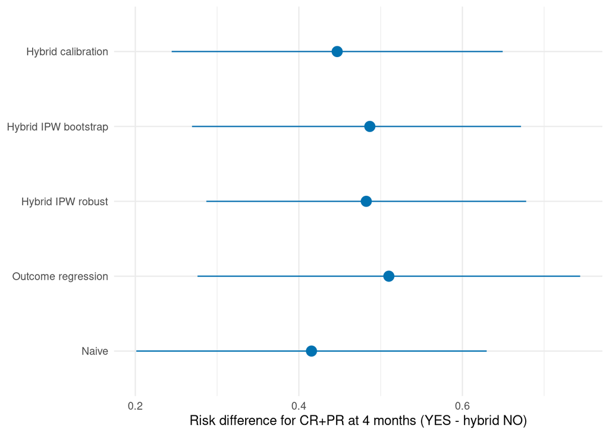

```r
bind_rows(
  # naive OLS estimates
  naive_ml %>%
    tidy(conf.int = TRUE) %>%
    filter(term == "treat_drugYES") %>%
    dplyr::select(estimate, conf.low, conf.high) %>%
    mutate(type = "Naive"),

  # outcome model estimates
  outcome_ml %>%
    tidy(conf.int = TRUE) %>%
    filter(term == "treat_drugYES") %>%
    dplyr::select(estimate, conf.low, conf.high) %>%
    mutate(type = "Outcome regression"),

  # hybrid ATT IPW estimates
  hybrid_att_results %>%
    dplyr::select(estimate, conf.low, conf.high) %>%
    mutate(type = "Hybrid IPW robust"),

  # bootstrap estimates for the hybrid ATT IPW analysis
  boot_estimate_hybrid %>%
    dplyr::select(
      estimate = .estimate,
      conf.low = .lower,
      conf.high = .upper
    ) %>%
    mutate(type = "Hybrid IPW bootstrap"),

  # hybrid calibration weighting estimates
  cal_estimate_robust_hybrid %>%
    dplyr::select(estimate, conf.low, conf.high) %>%
    mutate(type = "Hybrid calibration")
) %>%
  arrange() %>%
  mutate(type = forcats::fct_inorder(type)) %>%
  ggplot(aes(x = type, y = estimate, ymin = conf.low, ymax = conf.high)) +
  geom_pointrange(color = "#0172B1", size = 1, fatten = 3) +
  coord_flip() +
  theme_minimal() +
  theme(axis.title.y = element_blank()) +
  labs(
    x = NULL,
    y = "Risk difference for CR+PR at 4 months (YES - hybrid NO)"
  )
```

# 10 Sensitivity analysis for unmeasured confounding

```r
# https://louisahsmith.github.io/evalue/reference/evalues.RD.html
n11_w <- with(
  df_hybrid_att,
  sum(hybrid_w * (treat_drug == "YES") * (cr_pr_4m == 1))
)
n10_w <- with(
  df_hybrid_att,
  sum(hybrid_w * (treat_drug == "YES") * (cr_pr_4m == 0))
)
n01_w <- with(
  df_hybrid_att,
  sum(hybrid_w * (treat_drug == "NO") * (cr_pr_4m == 1))
)
n00_w <- with(
  df_hybrid_att,
  sum(hybrid_w * (treat_drug == "NO") * (cr_pr_4m == 0))
)

#' Returns E-values for the point estimate and the lower confidence interval limit
#' for a positive risk difference. If the risk difference is negative, the exposure
#'  coding should be first be reversed to yield a positive risk difference.
EValue::evalues.RD(n11_w, n10_w, n01_w, n00_w)
```

```
$est.Evalue
[1] 13.5346

$lower.Evalue
[1] 5.449288
```

```r
# for tipping point analysis, tipr package does not have calculation for RD measures.
```